```python
import pandas as pd
import numpy as np
import matplotlib.pyplot as plt
import seaborn as sns
import scipy
from pylab import rcParams
rcParams['figure.figsize'] = 25, 15
```

# Problem 1: Descriptive Statistics and Probability Theory: Real Data on CEO Compensation

## 1. In the pre-reading you/we have discussed tools and methods for visualizing data and computing some simple characteristic measures. Our aim here is to apply all the basic techniques and to draw correct conclusions. The file ceo.xls contains data on the CEO compensations and some additional variables listed below.

- salary = 1999 salary + bonuses in 1000 US$
- totcomp = 1999 CEO total compensation
- tenure = # of years as CEO (=0 if less than 6 months)
- age = age of CEO
- sales = total 1998 sales revenue of firm i
- profits = 1998 profits for firm i
- assets = total assets of firm i in 1998

```python
df = pd.read_excel('ceo.xls', usecols=range(7))
df.head()
```

|  | salary | totcomp | tenure | age | sales | profits | assets |
| --- | --- | --- | --- | --- | --- | --- | --- |
| 0 | 3030 | 8138 | 7 | 61 | 161315.0 | 2956.0 | 257389.0 |
| 1 | 6050 | 14530 | 0 | 51 | 144416.0 | 22071.0 | 237545.0 |
| 2 | 3571 | 7433 | 11 | 63 | 139208.0 | 4430.0 | 49271.0 |
| 3 | 3300 | 13464 | 6 | 60 | 100697.0 | 6370.0 | 92630.0 |
| 4 | 10000 | 68285 | 18 | 63 | 100469.0 | 9296.0 | 355935.0 |

## (a)

For the variable totcomp compute the common location measures:

- mean
- 5%- trimmed mean
- median
- upper and lower quartiles
- the upper and lower 5%- quantiles

Give an economic interpretation for every location measure.

- Mean

```python
totcomp = np.array(sorted(df['totcomp']))
```

```python
totcomp_mean = df['totcomp'].mean()

print("CEO total compensation mean: {:.2f}".format(totcomp_mean))
```

```
CEO total compensation mean: 8340.06
```

- 5%-trimmed mean

```python
def trim_X(X, alpha=0.05):
    N = len(X)
    a = int(N * alpha)
    return X[a:-a]
```

```python
trimmed_totcomp = trim_X(totcomp, 0.05)
trim_totcomp_mean = trimmed_totcomp.mean()

print("CEO total compensation 5%-trimmed mean: {:.2f}".format(trim_totcomp_mean))
```

```
CEO total compensation 5%-trimmed mean: 4637.68
```

Because we have an outliers, 5% trimmed mean gives a less mean.

- median

```python
def get_p_quantile(X, p):
    N = len(X)
    NP = int(N * p)
    if N % 2  == 0:
        Xp = (X[NP] + X[NP + 1])/2.
    else:
        Xp = X[NP]
    return Xp
```

```python
totcomp_median = get_p_quantile(totcomp, 0.5)

print("CEO total compenstation median: ", totcomp_median)
```

```
CEO total compenstation median:  2951
```

50% of people recieve less, than 2951

- The upper and lower quartiles

```python
# tcmp - totcomp

tcmp_upper_q, tcmp_lower_q = get_p_quantile(totcomp, 0.75), get_p_quantile(totcomp, 0.25)

print("CEO total compensation upper quartile: ", tcmp_upper_q)
print("CEO total compensation lower quartile: ", tcmp_lower_q)
print("25% of people recieve less, than 1573")
print("75% of people recieve less, than 6053")
```

```
CEO total compensation upper quartile:  6053
CEO total compensation lower quartile:  1573
25% of people recieve less, than 1573
75% of people recieve less, than 6053
```

- The upper and lower 5%-quantiles

```python
tcmp5_upper_q, tcmp5_lower_q = get_p_quantile(trimmed_totcomp, 0.75), get_p_quantile(trimmed_totcomp, 0.25)

print("CEO total compensation upper quartile: ", tcmp5_upper_q)
print("CEO total compensation lower quartile: ", tcmp5_lower_q)
print("25% of people without outliers recieve less, than 1573")
print("75% of people without outliers recieve less, than 6053")
```

[output not shown]

## (b)

Plot the empirical cumulative distribution function. Compute and explain in economic terms the following quantities

- $\hat{F}^{-1}(0.1)$ and $F^{-1}(0.9)$
- $F(2000)$ and $1 - F(4000)$

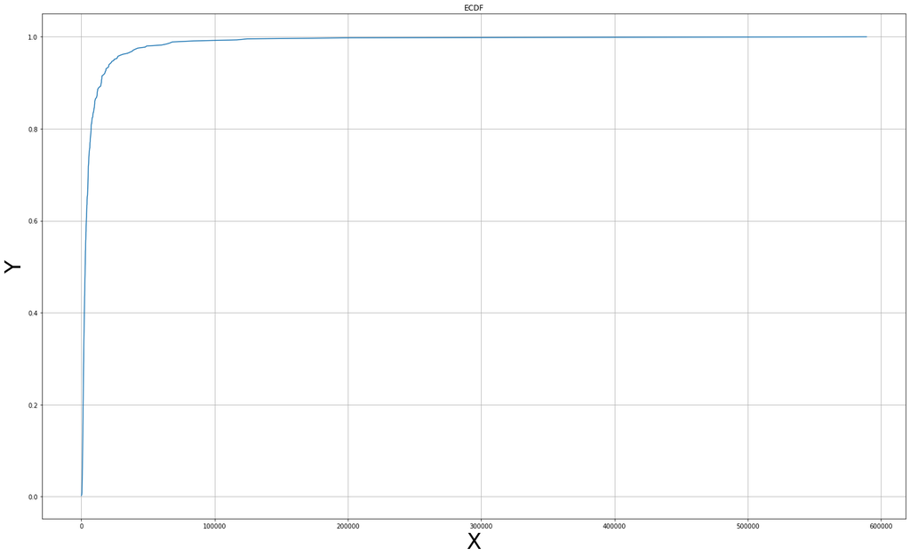

```python
def ecdf(data):
    """Compute ECDF"""
    x = np.sort(np.unique(data))
    y = []
    for v in x:
        y.append(len(data[data <= v])/len(data))
    return x, y

plt.figure(figsize=(25, 15))
x, y = ecdf(totcomp)
plt.plot(x, y);
plt.title('ECDF')
plt.xlabel('X', fontsize=35)
plt.ylabel('Y', fontsize=35)
plt.grid()
plt.show()
```

- $\hat{F}^{-1}(0.1)$ and $\hat{F}^{-1}(0.9)$

```python
def f_hat_inv(data, p):
    data = np.sort(data)
    N = data.size

    return data[int(N * p)]

f_inv_low, f_inv_high = f_hat_inv(totcomp, 0.1), f_hat_inv(totcomp, 0.9)

print("10% CEO total compensation amount: ", f_inv_low)
print("90% CEO total compensation amount: ", f_inv_high)
```

```
10% CEO total compensation amount:  1000
90% CEO total compensation amount:  15133
```

```python
def f_hat(data, x):
    data = np.sort(np.unique(data))
    N = data.size

    return np.where(data <= x)[0][-1] / N

print("{}% percentage of people with salary <= 2000".format(int(f_hat(totcomp, 2000) * 100)))
print("{}% percentage of people with salary >= 4000".format(int((1. - f_hat(totcomp, 4000)) * 100)))
```

```
32% percentage of people with salary <= 2000
40% percentage of people with salary >= 4000
```

## (c)

Plot the histogram of totcomp and the Box-plot (or violin-plot). What can be concluded about the distribution of the data? Are the location measures computed above still appropriate? Compute and discuss an appropriate measure of symmetry.

```python
sns.set(style="whitegrid")
```

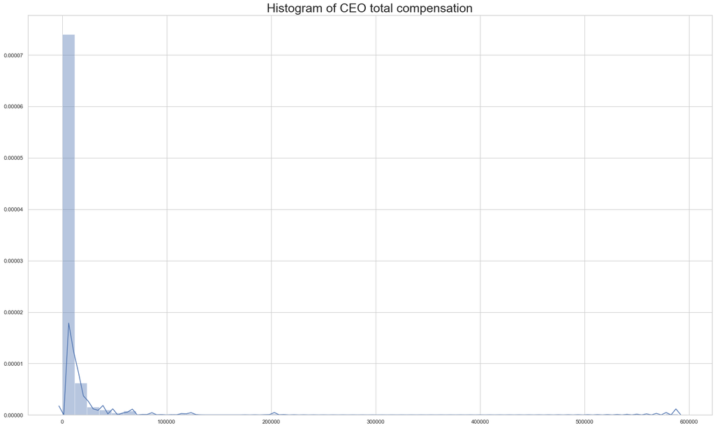

```python
plt.figure(figsize=(25, 15))
plt.title("Histogram of CEO total compensation", fontsize=25)
sns.distplot(totcomp);
```

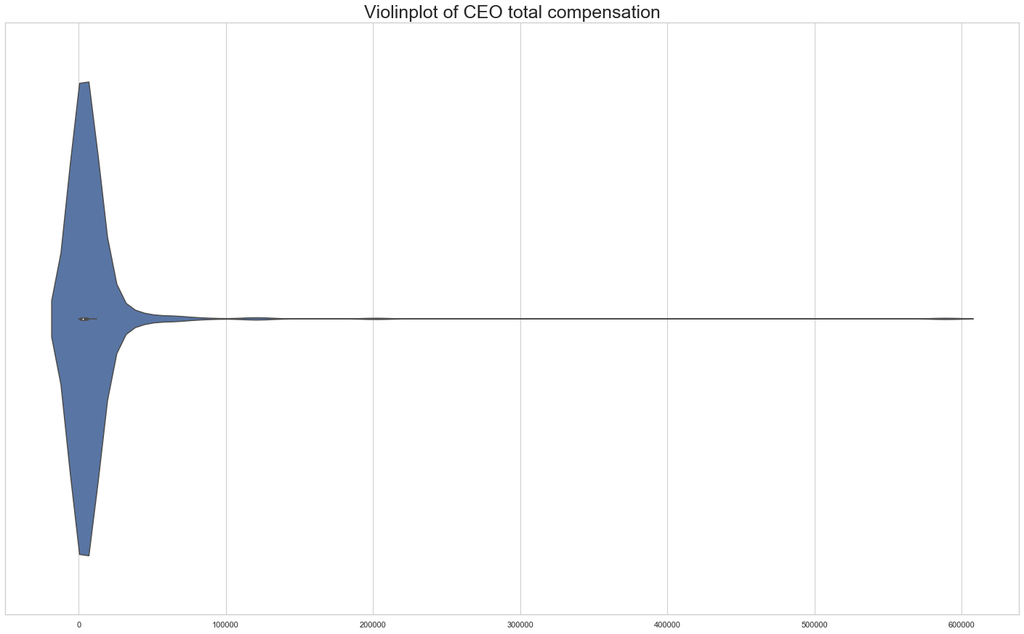

```python
plt.figure(figsize=(25, 15))
plt.title("Violinplot of CEO total compensation", fontsize=25)
sns.violinplot(totcomp);
```

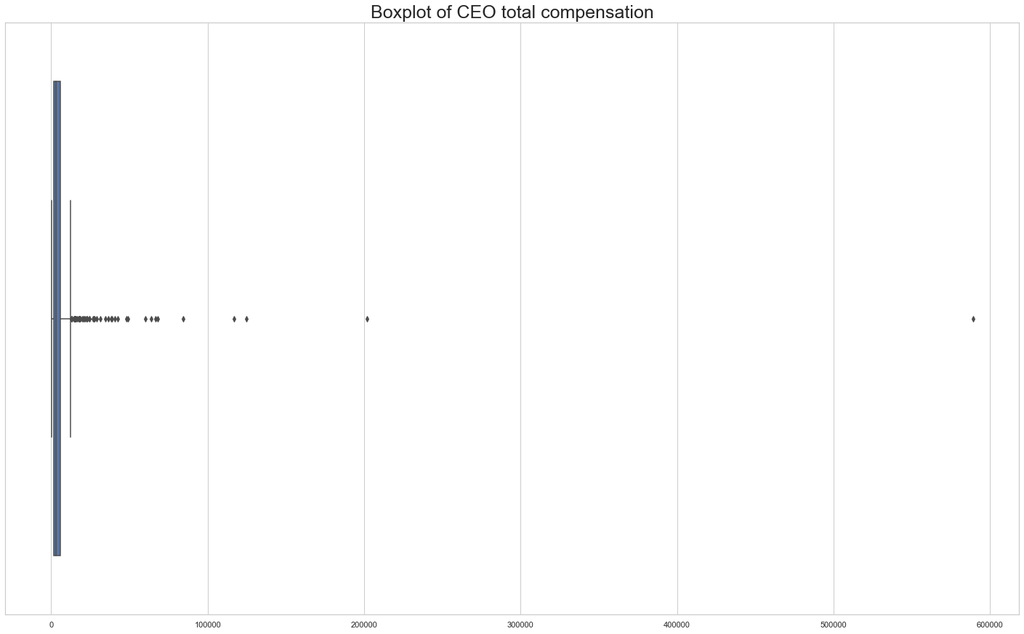

```python
plt.figure(figsize=(25, 15))
plt.title("Boxplot of CEO total compensation", fontsize=25)
sns.boxplot(totcomp);
```

Compute and discuss an appropriate measure of symmetry.

```python
def sample_variance(X):

    mu = np.mean(X)
    n = len(x)

    s2 = np.sum((X - mu)**2) / (n - 1)

    return s2
```

```python
def empirical_skewness(X):
    s = np.sqrt(sample_variance(X))
    mu = np.mean(X)
    n = len(X)

    sk = np.sum(((X - mu)/s)**3) / n

    return sk
```

```python
print("Skewness of totcomp is : {:.2f}".format(empirical_skewness(totcomp)))
```

```
Skewness of totcomp is : 13.91
```

## (d)

Check which method is used in your software to compute the optimal bandwidth (or the number of bars) in the histogram. Describe it shortly here. Make plots of too detailed and too rough histograms. What can we learn from these figures?

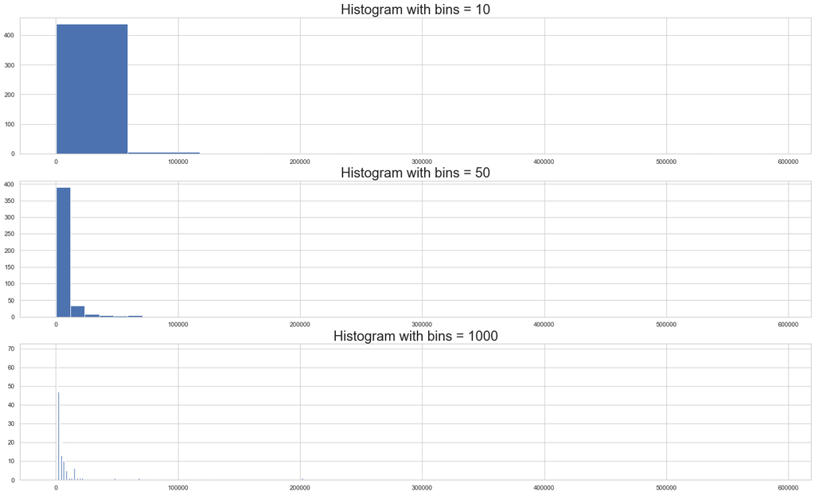

```python
fig, axs = plt.subplots(3, 1)

axs[0].set_title("Histogram with bins = 10", fontsize=24)
axs[0].hist(totcomp, bins=10);

axs[1].set_title("Histogram with bins = 50", fontsize=24)
axs[1].hist(totcomp, bins=50);

axs[2].set_title("Histogram with bins = 1000", fontsize=24)
axs[2].hist(totcomp, bins=1000);
```

If the number of bins is too low, bins are so wide that it overlaps most of the data. If the numbers of bins are too high, there are too many free space between rectangles. Plotly by default use 10 number of bins. But there are a lot more precise algorithms, for example, Freedman Diaconis Estimator.

## (e)

There are methods which help us make the distribution of the sample more sym- metric. Consider the natural logarithm of the total compensation: ln(totcomp). Plot the histogram (and Box-plot) and compare it with the figures for the original data. Compute the mean and the median. What can be concluded from the new values? Provide economic interpretation.

```python
ln_totcomp = np.log(totcomp)
```

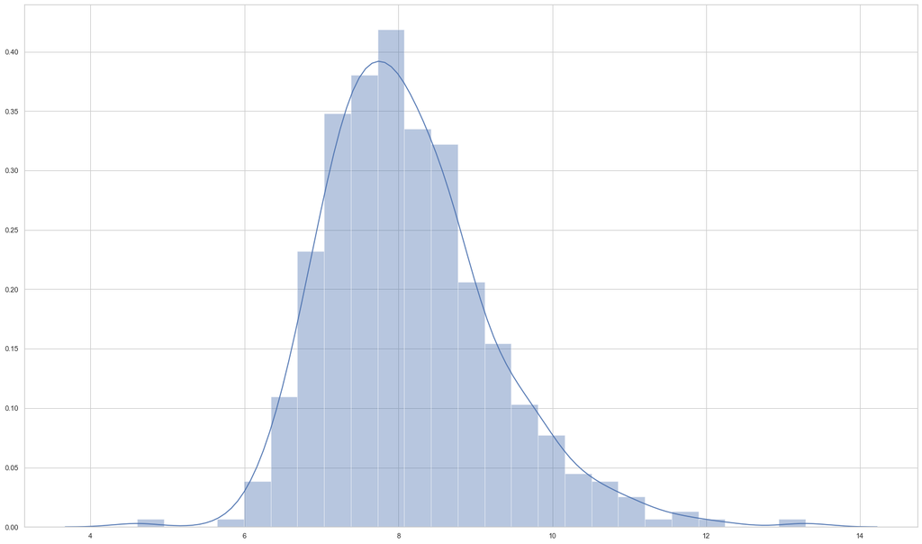

```python
sns.distplot(ln_totcomp);
```

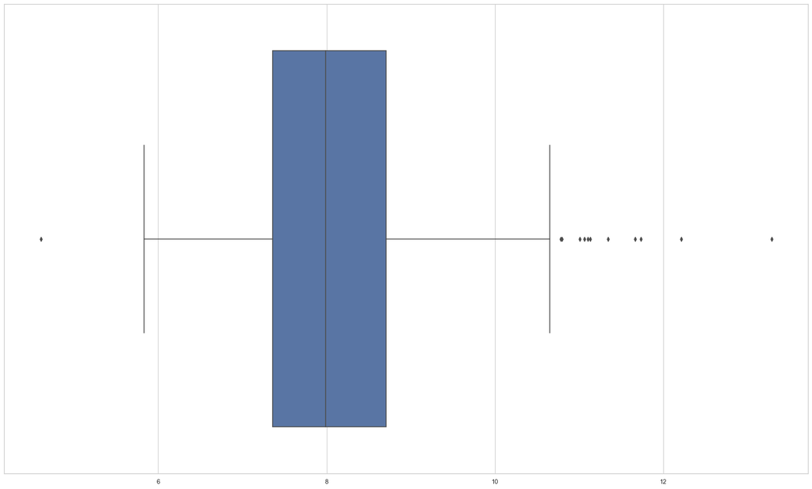

```python
sns.boxplot(ln_totcomp);
```

```python
ln_totcomp_mean = ln_totcomp.mean()

print("Logarithm CEO total compensation mean: ", ln_totcomp_mean)
```

```
Logarithm CEO total compensation mean:  8.135686093478537
```

```python
ln_totcomp_median = ln_totcomp[int(len(ln_totcomp)/2)]

print("Logarithm CEO total compensation median: ", ln_totcomp_median)
```

```
Logarithm CEO total compensation median:  7.989899374942939
```

1. Next we try to make a more detailed analysis of the data (without logarithm).

(a) We suspect that the total compensation of the CEO and other variables are re- lated. Compute the correlation coefficients of Pearson and plot them as a heatmap (correlation map). Discuss the strength of the correlations.

```python
df.head()
```

|  | salary | totcomp | tenure | age | sales | profits | assets | Unnamed: 7 |
| --- | --- | --- | --- | --- | --- | --- | --- | --- |
| 0 | 3030 | 8138 | 7 | 61 | 161315.0 | 2956.0 | 257389.0 | NaN |
| 1 | 6050 | 14530 | 0 | 51 | 144416.0 | 22071.0 | 237545.0 | NaN |
| 2 | 3571 | 7433 | 11 | 63 | 139208.0 | 4430.0 | 49271.0 | NaN |
| 3 | 3300 | 13464 | 6 | 60 | 100697.0 | 6370.0 | 92630.0 | NaN |
| 4 | 10000 | 68285 | 18 | 63 | 100469.0 | 9296.0 | 355935.0 | NaN |

```python
df = df.iloc[:, :-1]
df.head()
```

[output not shown]

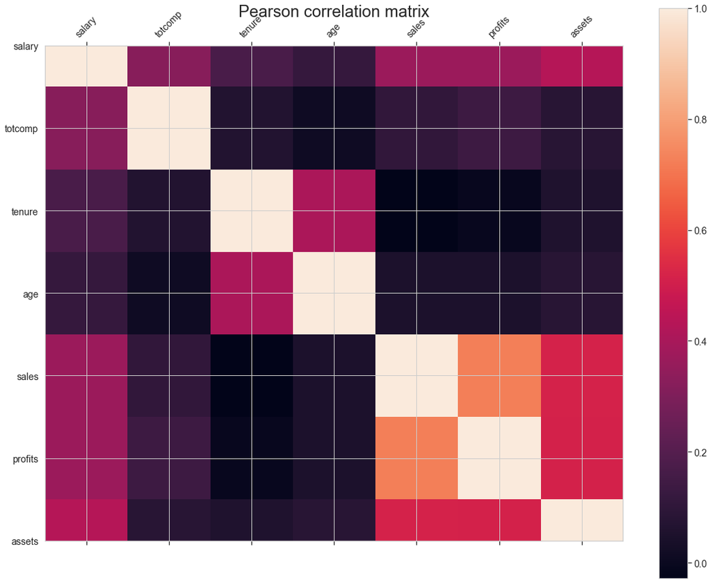

```python
f = plt.figure(figsize=(19, 15))
plt.matshow(df.corr(), fignum=f.number)
plt.xticks(range(df.shape[1]), df.columns, fontsize=14, rotation=45)
plt.yticks(range(df.shape[1]), df.columns, fontsize=14)
cb = plt.colorbar()
cb.ax.tick_params(labelsize=14)
plt.title("Pearson correlation matrix", fontsize=24)
plt.show()
```

Sales and profits are correlated, also sales and profits with assets a bit correlated too.

(b) Plot the scatter plots (pairs in R). Conclude if the linear correlation coefficients are appropriate here. Compute now the Spearman’s correlations and make a heatmap. Compare the results with Pearson. What is the rank of the observation totcomp= 6000?

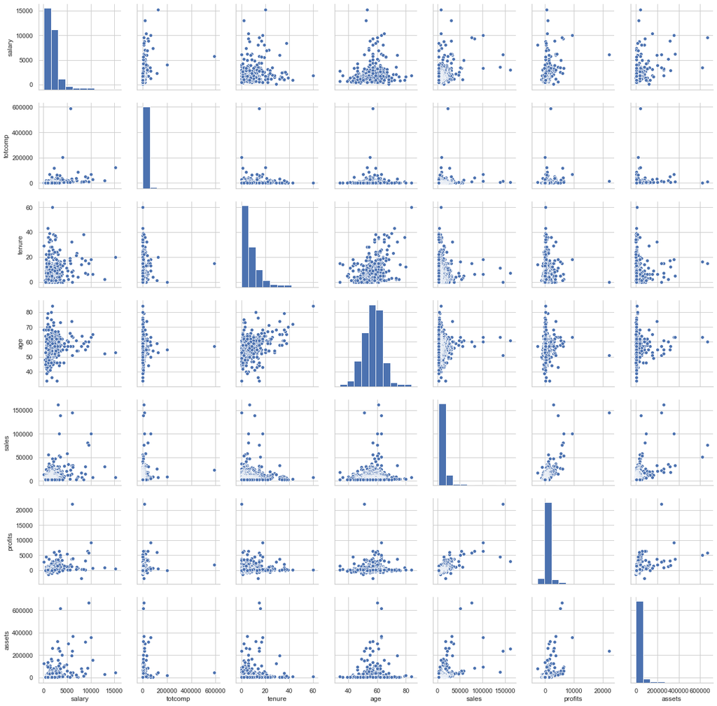

```python
plt.figure(figsize=(15, 25))
sns.pairplot(df);
```

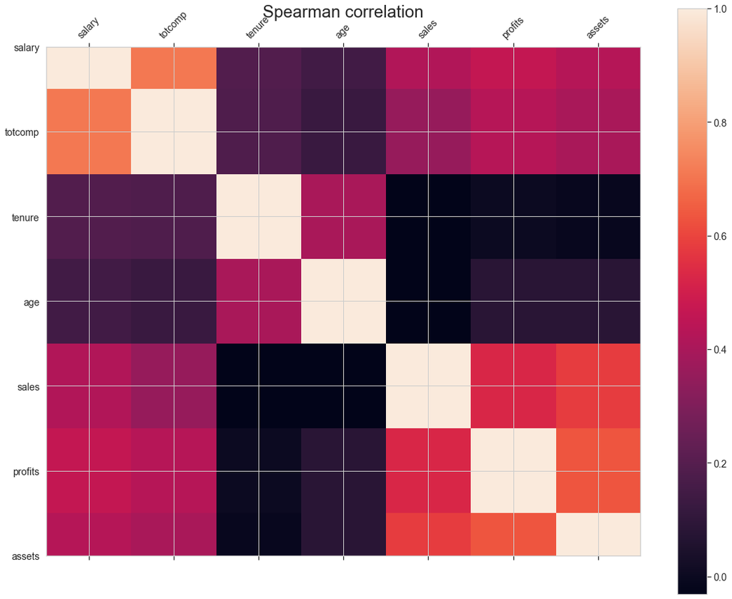

```python
f = plt.figure(figsize=(19, 15))
plt.matshow(df.corr(method='spearman'), fignum=f.number)
plt.xticks(range(df.shape[1]), df.columns, fontsize=14, rotation=45)
plt.yticks(range(df.shape[1]), df.columns, fontsize=14)
cb = plt.colorbar()
cb.ax.tick_params(labelsize=14)
plt.title("Spearman correlation", fontsize=24)
plt.show()
```

(c) Consider the two subsamples: CEOs younger than 50 and older than 50. Plot for both subsamples overlapping histograms/ecdf’s and discuss the results. What can we learn from the corresponding location and dispersion (!) measures?

```python
df_young, df_old = df[df['age'] < 50], df[df['age'] >= 50]
```

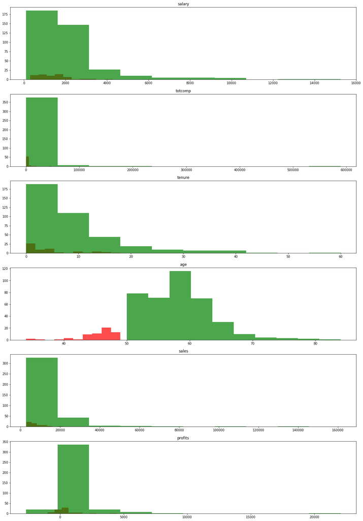

```python
fig, axs = plt.subplots(6, 1, figsize=(20, 30))

for i, column in enumerate(df.columns):
    axs[i].set_title(column)
    axs[i].hist(df_young[column], color='r', alpha=0.7)
    axs[i].hist(df_old[column], color='g', alpha=0.7)
```

1. Consider another grouping of the data. Define the groups:

```python
S1, S2, S3 = df['salary'] < 3000, (df['salary'] >= 3000) & (df['salary'] < 5000), df['salary'] > 5000

A1, A2 = df['age'] < 50, df['salary'] >= 50

S = [S1, S2, S3]
S_names = ['salary < 3k', '3k >= salary < 5k', 'salary >= 5k']
A = [A1, A2]
A_names = ['age < 50', 'age >= 50']
```

(a) Aggregate the data to a 2 × 3 contigency table with absolute and with relative frequencies.

```python
con_table = pd.crosstab(A, S, rownames=A_names, colnames=S_names, margins=True)
con_table
```

| age < 50 | salary < 3k 3k >= salary < 5k salary >= 5k age >= 50 | False | False True | False True | True False | All |
| --- | --- | --- | --- | --- | --- | --- |
| False | True | 1 | 24 | 37 | 323 | 385 |
| True | True | 0 | 0 | 3 | 59 | 62 |
| All |  | 1 | 24 | 40 | 382 | 447 |

```python
con_table_norm = pd.crosstab(A, S, rownames=A_names, colnames=S_names, normalize=True)
con_table_norm
```

| age < 50 | salary < 3k 3k >= salary < 5k salary >= 5k age >= 50 | False | False True | False True | True False |
| --- | --- | --- | --- | --- | --- |
| False | True | 0.002237 | 0.053691 | 0.082774 | 0.722595 |
| True | True | 0.000000 | 0.000000 | 0.006711 | 0.131991 |

(b) Give interpretation for the values of n12, h12, n1· and h1·.

```python
# Absolute frequency (n12)

n12 = con_table.iloc[0, 1]
print("Number of old people, who have more than 5k salary: ", n12)
```

```
Number of old people, who have more than 5k salary:  24
```

```python
# Relative frequency (h12)

h12 = con_table.iloc[0, 1]/con_table.iloc[-1, -1]
print("Percentage of old people, who have more than 5k salary - {}%".format(int((h12) * 100)))
```

```
Percentage of old people, who have more than 5k salary - 5%
```

```python
# Absolute marginal frequency (n1)

n1 = con_table.iloc[0, -1]
print("Number of people with age >= 50:  ", n1)
```

```
Number of people with age >= 50:   385
```

```python
# Also relative frequency (h1)

h1 = con_table.iloc[0, -1] / con_table.iloc[-1, -1]

print("Percentage of people with age >= 50 among all people: {}%".format(int(h1 * 100)))
```

```
Percentage of people with age >= 50 among all people: 86%
```

(c) Compute an appropriate dependence measure for Si and Aj. What can be con- cluded from its value?

```python
def compute_dependency(table):
    d = 0
    for i in range(table.shape[0]):
        for j in range(table.shape[1]):
            nij = table.iloc[i, j]
            ni = table.iloc[i, -1]
            nj = table.iloc[-1, j]
            n = table.iloc[-1, -1]
            d += ((nij - (ni * nj)/n)**2)/ (ni * nj / n)
    return d
```

```python
print("Dependency of data : {:.2f}, It's mean, that older CEO earns more, than younder CEO.".format(compute_dependency(con_table)))
```

```
Dependency of data : 6.18, It's mean, that older CEO earns more, than younder CEO.
```

# Problem 2: Descriptive Statistics and Probability Theory: Simulated Data

It is obvious that the descriptive tools are very sensitive to contamination or outliers in the data. The objective of this problem is to assess the sensitivity of these measures/tools to outliers or very heterogenous data.

1. Simulate (with a fixed seed) a sample of size n = 100 from the normal distribution with $μ_{1} = 10$ and $\sigma_{2}^2 = 9$

```
(a) Plot the histogram and compare it to the density of N(10,9).
```

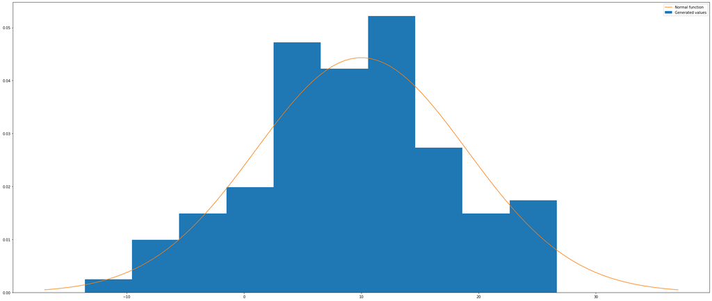

```python
np.random.seed(42)

mu = 10
sigma = 9
X = np.random.normal(loc=mu, scale=sigma, size=100)
N = np.linspace(mu - 3*sigma, mu + 3*sigma, 100)
plt.hist(X, normed=True, label='Generated values')
plt.plot(N, scipy.stats.norm.pdf(N, mu, sigma), label='Normal function')
plt.legend()
plt.plot();
```

(b) Now draw a sample yi of size n = 100 from $t_{5}$. Transform it as follows: $10 + 3\sqrt{3/5} · y_i$. Plot the histogram and compare the density of $N(10, 9)$. What can be concluded and why this example might be relevant for empirical studies?

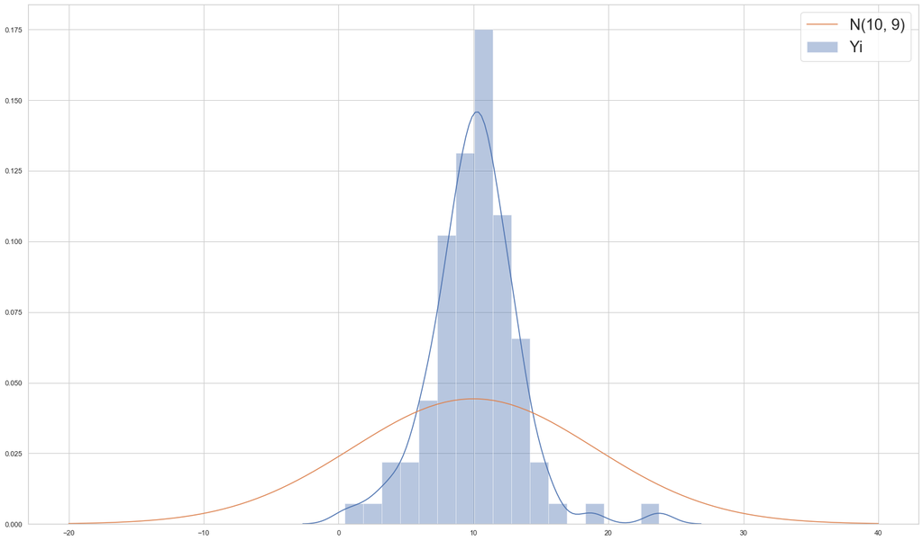

```python
dof = 5

Yi = np.random.standard_t(dof, size=100)
Yi = 10. + 3. * np.sqrt(0.6) * Yi

sns.distplot(Yi, label="Yi")

x = np.linspace(-20, 40, 100)
y = scipy.stats.norm.pdf(x, 10, 9)

plt.plot(x, y, label="N(10, 9)")
plt.legend(fontsize=24)
plt.show();
```

1. In practice the data is always very heterogenous. To reflect it we contaminate the data by adding an outlier or a subsample with different characteristics.

```python
mu = 10
sigma = 9
X = np.random.normal(loc=mu, scale=sigma, size=100)

X_20 = np.random.normal(loc=20, scale=4, size=20)
# X_20 = np.concatenate([X, ])
X_100 = np.random.normal(loc=20, scale=4, size=100)
# X_100 = np.concatenate([X, ])
```

(b) Plot Box-plots (or violin plots) and histograms for each subsample individually and for the sample for a few different values of m.

[figure not shown]

```python
fig, (ax1, ax2) = plt.subplots(2, 2, figsize=(30, 30))

ax1[0].set_title("Random distribution histogram", fontsize=24)
sns.distplot(X, ax=ax1[0], label="mu = 10, sigma = 9")
sns.distplot(X_20, ax=ax1[0], label="mu = 20, sigma = 4")
ax1[0].legend(fontsize=24)


ax1[1].set_title("Random distribution violinplot with m = 20 additional noise", fontsize=24)
sns.violinplot(y=X_20, ax=ax1[1])

ax2[0].set_title("Random distribution histogram with m = 100 additional noise", fontsize=24)
sns.distplot(X_100, ax=ax2[0])

ax2[1].set_title("Random distribution violinplot with m = 100 additional noise", fontsize=24)
sns.violinplot(y=X_100, ax=ax2[1])

plt.show();
```

1. Next step is to simulate two dependent data sets. We simulate two samples with a given value of the correlation coefficient.

```python
U = np.random.normal(0, 1, 10000000)
V = np.random.normal(0, 1, 10000000)
```